# Staples PE

Hypothesis : E of the Product depends on Demand Loyalty than Price Competetiveness.

Null Hypothesis : E of the Product depends on Price Competetiveness than Demand Loyalty.

Alternate Hypothesis : E of the Product depends on Demand Loyalty than Price Competetiveness.

HIGH DL

Correlation Matrix with Equally distributed Observations.

```
## $HIGH
##                 PC_SA Conversion
## PC_SA       1.0000000 -0.1499292
## Conversion -0.1499292  1.0000000
##
## $LOW
##               PC_SA Conversion
## PC_SA      1.000000   0.223528
## Conversion 0.223528   1.000000
```

```
##
## HIGH  LOW
##  220  219
```

- Note : No. of Observations are equally distributed based on DL(Sorted).
- Inference : When DL is HIGH, Conversion & PC are Weekly Negatively Correlated.
- Inference : When DL is LOW, Conversion & PC are Weekly Postively Correlated.

```
## $HIGH
##                 PC_SA Conversion
## PC_SA       1.0000000 -0.2118276
## Conversion -0.2118276  1.0000000
##
## $LOW
##            PC_SA Conversion
## PC_SA         NA         NA
## Conversion    NA         NA
##
## $MID
##                PC_SA Conversion
## PC_SA      1.0000000  0.1529794
## Conversion 0.1529794  1.0000000
```

```
##
## HIGH  LOW  MID
##  127   18  294
```

Below is the correlation matrix after collating “HIGH” & “MID” as one and “LOW” as other. HIGH>75% LOW Otherwise

```
## $HIGH
##                  PC_SA  Conversion
## PC_SA       1.00000000 -0.07685417
## Conversion -0.07685417  1.00000000
##
## $LOW
##                 PC_SA Conversion
## PC_SA       1.0000000 -0.6252245
## Conversion -0.6252245  1.0000000
```

```
##
## HIGH  LOW
##  421   18
```

- Inference : When DL is HIGH(combined HIGH & MID), Conversion & PC are weekly negatively correlated.
- Inference : When DL is LOW, Coversion & PC are Strongly negatively correlated.

Relationship between Conversion & Price Competetiveness : Cut-off : HIGH > 75%(default), LOW Otherwise

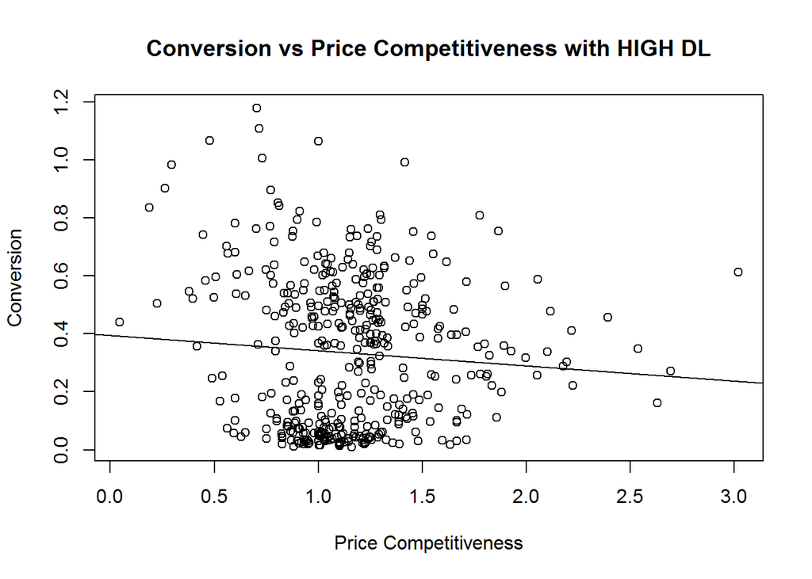

- Inference : When DL is HIGH, as Price competitiveness Increases Conversion decreases.

Change in Cut-off i.e; HIGH > 67%, LOW otherwise

```
## $HIGH
##                 PC_SA Conversion
## PC_SA       1.0000000 -0.3187486
## Conversion -0.3187486  1.0000000
##
## $LOW
##                  PC_SA  Conversion
## PC_SA       1.00000000 -0.04890732
## Conversion -0.04890732  1.00000000
```

```
##
## HIGH  LOW
##   21  418
```

- Inference : When DL is HIGH, Conversion & PC are weekly negatively correlated.
- Inference : When DL is LOW, Conversion & PC are poorly negatively correlated.

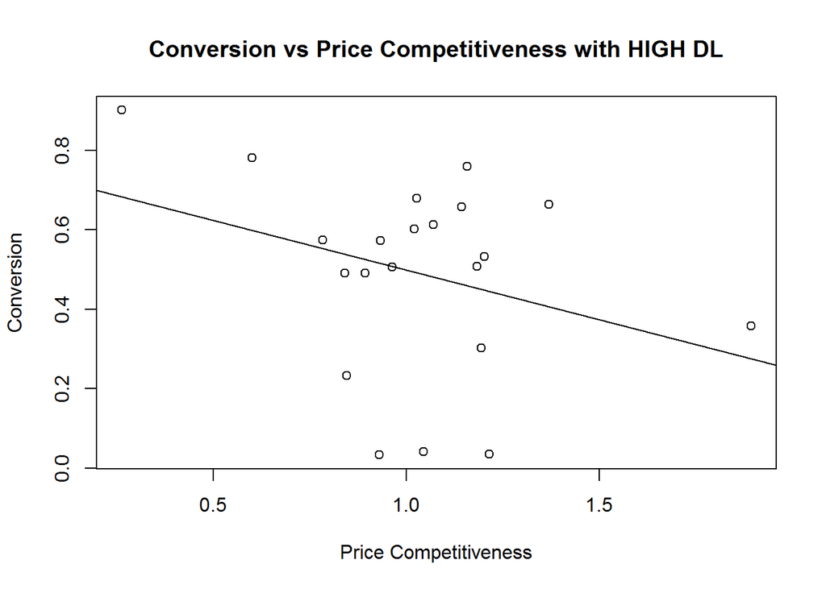

- Inference : If DL is HIGH, as Price competitiveness Increases Conversion decreases.

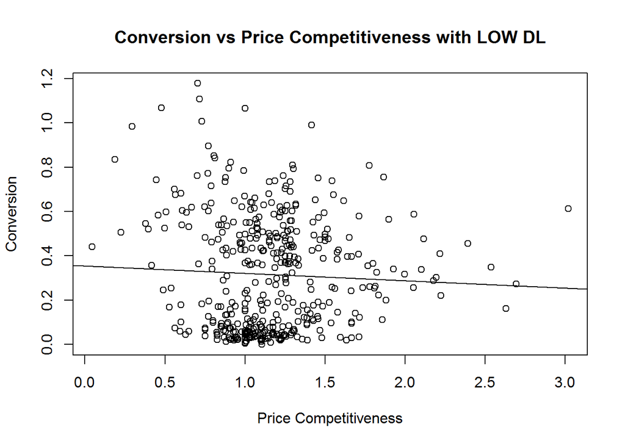